# `mice`: a quick practical guide

Gerko Vink and Stef van Buuren

The aim of this guide is to make you familiar with mice in `R` and to enhance your understanding of multiple imputation, in general. You will learn how to perform and inspect multiple imputations and how to pool the results of analyses performed on multiply-imputed data, how to approach different types of data and how to avoid some of the pitfalls many data scientists may fall into. The main objective is to increase your knowledge and understanding on applications of multiple imputation.

We start by loading (with `library()`) the necessary packages and fixing the random seed to allow for our outcomes to be replicable.

```r
library(mice)    # data imputation
library(lattice) # plotting device
library(dplyr)   # data manipulation
library(magrittr)# pipes
library(purrr)   # functional programming
set.seed(123)
```

All the best,

[Gerko](https://www.gerkovink.com) and [Stef](http://www.stefvanbuuren.name)

# Multiple imputation with `mice`

The `mice` package contains several datasets. Once the package is loaded, these datasets can be used. Have a look at the `nhanes` dataset (Schafer, 1997, Table 6.14) by typing

```r
nhanes
```

```
##    age  bmi hyp chl
## 1    1   NA  NA  NA
## 2    2 22.7   1 187
## 3    1   NA   1 187
## 4    3   NA  NA  NA
## 5    1 20.4   1 113
## 6    3   NA  NA 184
## 7    1 22.5   1 118
## 8    1 30.1   1 187
## 9    2 22.0   1 238
## 10   2   NA  NA  NA
## 11   1   NA  NA  NA
## 12   2   NA  NA  NA
## 13   3 21.7   1 206
## 14   2 28.7   2 204
## 15   1 29.6   1  NA
## 16   1   NA  NA  NA
## 17   3 27.2   2 284
## 18   2 26.3   2 199
## 19   1 35.3   1 218
## 20   3 25.5   2  NA
## 21   1   NA  NA  NA
## 22   1 33.2   1 229
## 23   1 27.5   1 131
## 24   3 24.9   1  NA
## 25   2 27.4   1 186
```

The `nhanes` dataset is a small data set with non-monotone missing values. It contains 25 observations on four variables: *age group*, *body mass index*, *hypertension* and *cholesterol (mg/dL)*.

To learn more about the data, use one of the two following help commands:

```r
help(nhanes)
?nhanes
```

**1. Vary the number of imputations, such that the `nhanes` set is imputed $m=3$ times.**

The number of imputed data sets can be specified by the `m = ...` argument. For example, to create just three imputed data sets, specify

```r
imp <- mice(nhanes, m = 3, print=F)
```

**2. Change the predictor matrix**

The predictor matrix is a square matrix that specifies the variables that are used to impute each incomplete variable. Let us have a look at the predictor matrix that was used

```r
imp$pred
```

```
##     age bmi hyp chl
## age   0   1   1   1
## bmi   1   0   1   1
## hyp   1   1   0   1
## chl   1   1   1   0
```

Each variable in the data has a row and a column in the predictor matrix. A value `1` indicates that the column variable was used to impute the row variable. For example, the `1` at entry `[bmi, age]` indicates that variable `age` was used to impute the incomplete variable `bmi`. Note that the diagonal is zero because a variable is not allowed to impute itself. The row of `age` is redundant, because there were no missing values in `age`. Even though predictor relations are specified for `age`, `mice` will not use these relations because it will never overwrite the observed values with imputations. `mice` gives you complete control over the predictor matrix, enabling you to choose your own predictor relations. This can be very useful, for example, when you have many variables or when you have clear ideas or prior knowledge about relations in the data at hand.

There are two ways in which you can create a predictor matrix in `mice`:

- A. You can grab the `predictorMatrix` from every object returned by `mice()`:

For example, we can use `mice()` to give you us initial predictor matrix, and change it afterwards, without running the algorithm. This can be done by typing

```r
ini <- mice(nhanes, maxit=0, print=F)
pred <- ini$pred
pred
```

```
##     age bmi hyp chl
## age   0   1   1   1
## bmi   1   0   1   1
## hyp   1   1   0   1
## chl   1   1   1   0
```

The object `pred` contains the predictor matrix from an initial run of `mice` with zero iterations, specified by `maxit = 0`.

- B. We can use `make.predictorMatrix()` to generate a predictor matrix from any incomplete data set.

For example,

```r
pred <- make.predictorMatrix(nhanes)
pred
```

```
##     age bmi hyp chl
## age   0   1   1   1
## bmi   1   0   1   1
## hyp   1   1   0   1
## chl   1   1   1   0
```

Altering the predictor matrix and returning it to the mice algorithm is very simple. For example, the following code removes the variable `hyp` from the set of predictors, but still leaves it to be predicted by the other variables.

```r
pred[, "hyp"] <- 0
pred
```

```
##     age bmi hyp chl
## age   0   1   0   1
## bmi   1   0   0   1
## hyp   1   1   0   1
## chl   1   1   0   0
```

Use your new predictor matrix in `mice()` as follows

```r
imp <- mice(nhanes, predictorMatrix =  pred, print = F)
```

There is a `quickpred()` function that applies a quick selection procedure of predictors, which can be handy for datasets containing many variables. See `?quickpred` for more info. Selecting predictors according to data relations with a minimum correlation of $\rho=.30$ can be done by

```r
ini <- mice(nhanes, pred=quickpred(nhanes, mincor=.3), print=F)
ini$pred
```

```
##     age bmi hyp chl
## age   0   0   0   0
## bmi   1   0   0   1
## hyp   1   0   0   1
## chl   1   1   1   0
```

For large predictor matrices, it can be useful to export them to dedicated spreadsheet software like e.g. Microsoft Excel for easier configuration (e.g. see the [`xlsx` package](https://cran.r-project.org/web/packages/xlsx/index.html) for easy exporting and importing of Excel files). Importing data is straightforward in `RStudio` through `File` > `Import Dataset`.

**3. Inspect the convergence of the algorithm**

The `mice()` function implements an iterative Markov Chain Monte Carlo type of algorithm. Let us have a look at the trace lines generated by the algorithm to study convergence:

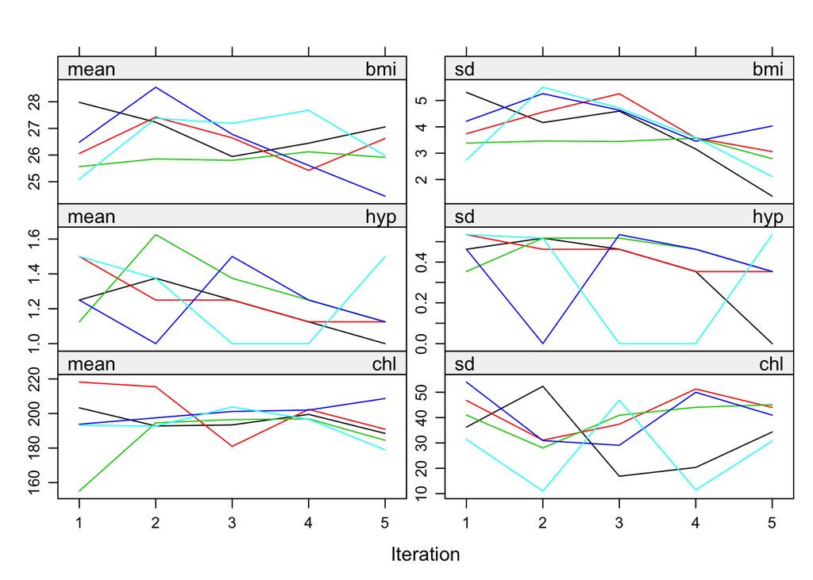

```r
imp <- mice(nhanes, print=F)
plot(imp)
```

The plot shows the mean (left) and standard deviation (right) of the imputed values only. In general, we would like the streams to intermingle and be free of any trends at the later iterations. We inspect trends for the imputed values alone, because the observed data does not change.

The `mice` algorithm uses random sampling, and therefore, the results will be (perhaps slightly) different if we repeat the imputations with different seeds. In order to get exactly the same result, use the `seed` argument

```r
imp <- mice(nhanes, seed=123, print=F)
```

where `123` is some arbitrary number that you can choose yourself. Rerunning this command will always yields the same imputed values.

**4. Change the imputation method**

For each column, the algorithm requires a specification of the imputation method. To see which method was used by default:

```r
imp$meth
```

```
##   age   bmi   hyp   chl
##    "" "pmm" "pmm" "pmm"
```

The variable `age` is complete and therefore not imputed, denoted by the `""` empty string. The other variables have method `pmm`, which stands for *predictive mean matching*, the default in `mice` for numerical and integer data.

In reality, the `nhanes` data are better described a as mix of numerical and categorical data. Let us take a look at the `nhanes2` data frame:

```r
summary(nhanes2)
```

```
##     age          bmi          hyp          chl
##  20-39:12   Min.   :20.40   no  :13   Min.   :113.0
##  40-59: 7   1st Qu.:22.65   yes : 4   1st Qu.:185.0
##  60-99: 6   Median :26.75   NA's: 8   Median :187.0
##             Mean   :26.56             Mean   :191.4
##             3rd Qu.:28.93             3rd Qu.:212.0
##             Max.   :35.30             Max.   :284.0
##             NA's   :9                 NA's   :10
```

and the structure of the data frame

```r
str(nhanes2)
```

```
## 'data.frame':    25 obs. of  4 variables:
##  $ age: Factor w/ 3 levels "20-39","40-59",..: 1 2 1 3 1 3 1 1 2 2 ...
##  $ bmi: num  NA 22.7 NA NA 20.4 NA 22.5 30.1 22 NA ...
##  $ hyp: Factor w/ 2 levels "no","yes": NA 1 1 NA 1 NA 1 1 1 NA ...
##  $ chl: num  NA 187 187 NA 113 184 118 187 238 NA ...
```

Variable `age` consists of 3 age categories, while variable `hyp` is binary. The `mice()` function takes these properties automatically into account. Impute the `nhanes2` dataset

```r
imp <- mice(nhanes2, print=F)
imp$meth
```

```
##      age      bmi      hyp      chl
##       ""    "pmm" "logreg"    "pmm"
```

Notice that `mice` has set the imputation method for variable `hyp` to `logreg`, which implements multiple imputation by *logistic regression*.

An up-to-date overview of the methods in mice can be found by

```r
methods(mice)
```

```
##  [1] mice.impute.2l.bin       mice.impute.2l.lmer
##  [3] mice.impute.2l.norm      mice.impute.2l.pan
##  [5] mice.impute.2lonly.mean  mice.impute.2lonly.norm
##  [7] mice.impute.2lonly.pmm   mice.impute.cart
##  [9] mice.impute.jomoImpute   mice.impute.lda
## [11] mice.impute.logreg       mice.impute.logreg.boot
## [13] mice.impute.mean         mice.impute.midastouch
## [15] mice.impute.mnar.logreg  mice.impute.mnar.norm
## [17] mice.impute.norm         mice.impute.norm.boot
## [19] mice.impute.norm.nob     mice.impute.norm.predict
## [21] mice.impute.panImpute    mice.impute.passive
## [23] mice.impute.pmm          mice.impute.polr
## [25] mice.impute.polyreg      mice.impute.quadratic
## [27] mice.impute.rf           mice.impute.ri
## [29] mice.impute.sample       mice.mids
## [31] mice.theme
## see '?methods' for accessing help and source code
```

Let us change the imputation method for `bmi` to Bayesian normal linear regression imputation

```r
meth <- make.method(nhanes2)
meth
```

```
##      age      bmi      hyp      chl
##       ""    "pmm" "logreg"    "pmm"
```

```r
meth["bmi"] <- "norm"
meth
```

```
##      age      bmi      hyp      chl
##       ""   "norm" "logreg"    "pmm"
```

and run the imputations again.

```r
imp <- mice(nhanes2, meth = meth, print=F)
```

We may now again plot trace lines to study convergence

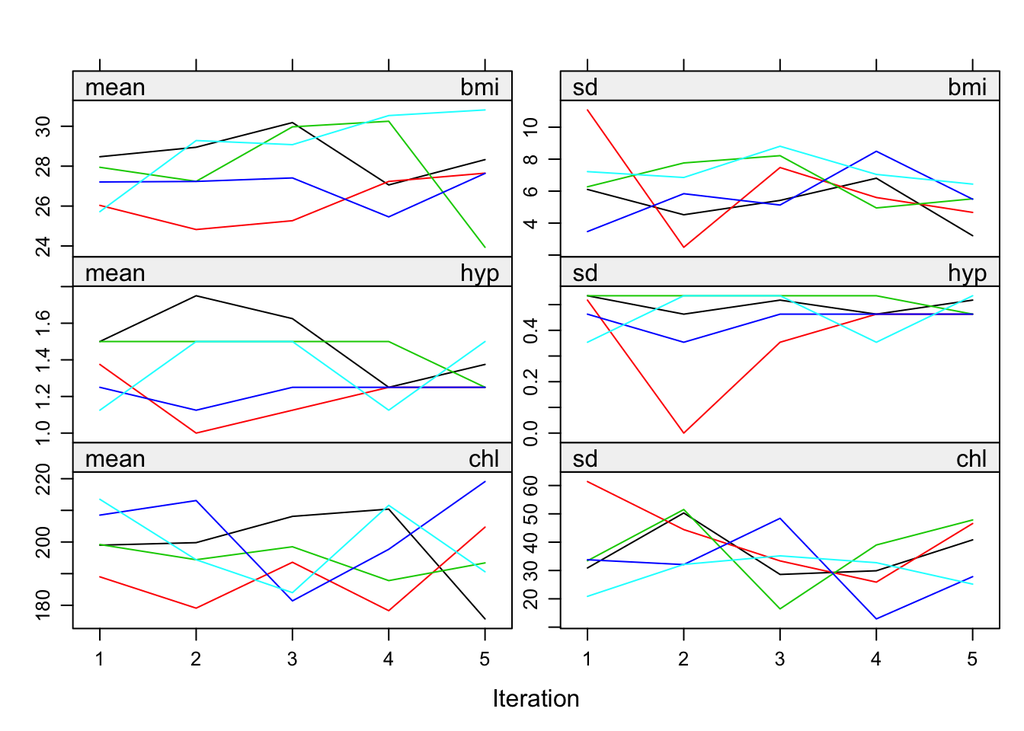

```r
plot(imp)
```

**5. Extend the number of iterations**

Though using just five iterations (the default) often works well in practice, we need to extend the number of iterations of the `mice` algorithm to confirm that there is no trend and that the trace lines intermingle well. We can increase the number of iterations to 40 by running 35 additional iterations using the `mice.mids()` function.

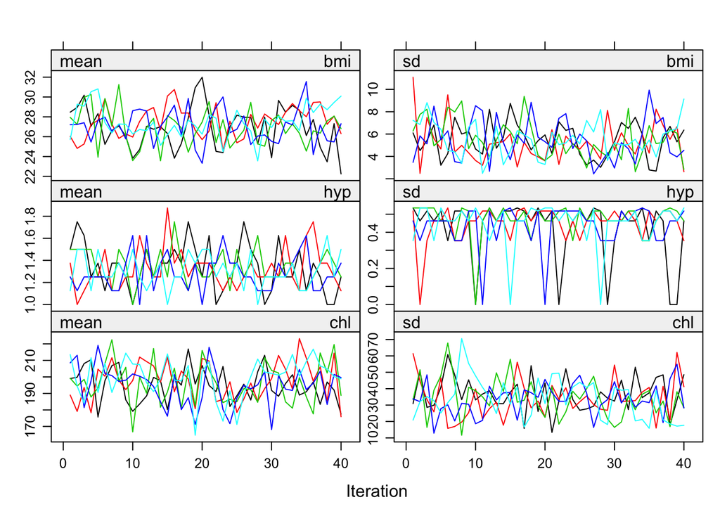

```r
imp40 <- mice.mids(imp, maxit=35, print=F)
plot(imp40)
```

**6. Further diagnostic checking. Use function `stripplot()`.**

Generally, one would prefer for the imputed data to be plausible values, i.e. values that could have been observed if they had not been missing. In order to form an idea about plausibility, one may check the imputations and compare them against the observed values. If we are willing to assume that the data are missing completely at random (MCAR), then the imputations should have the same distribution as the observed data. In general, distributions may be different because the missing data are MAR (or even MNAR). However, very large discrepancies need to be screened. Let us plot the observed and imputed data of `chl` by

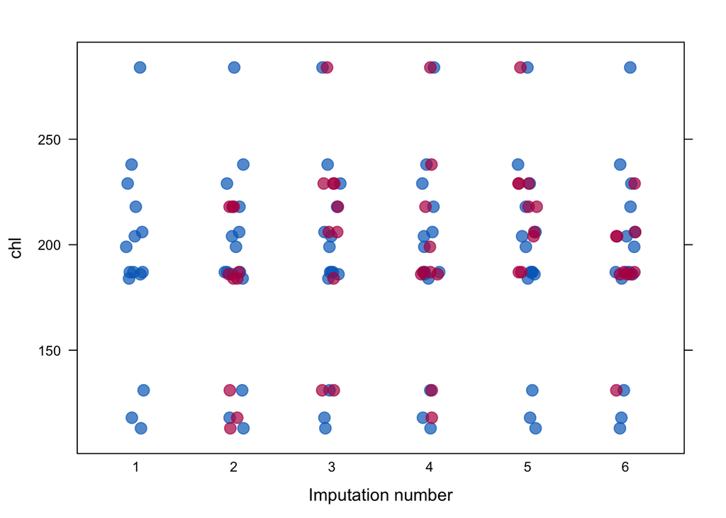

```r
stripplot(imp, chl~.imp, pch=20, cex=2)
```

The convention is to plot observed data in blue and the imputed data in red. The figure graphs the data values of `chl` before and after imputation. Since the PMM method draws imputations from the observed data, imputed values have the same gaps as in the observed data, and are always within the range of the observed data. The figure indicates that the distributions of the imputed and the observed values are similar. The observed data have a particular feature that, for some reason, thedata cluster around the value of 187. The imputations reflect this feature, and are close to the data. Under MCAR, univariate distributions of the observed and imputed data are expected to be identical. Under MAR, they can be different, both in location and spread, but their multivariate distribution is assumed to be identical. There are many other ways to look at the imputed data.

The following command creates a simpler version of the graph from the previous step and adds the plot for `bmi`.

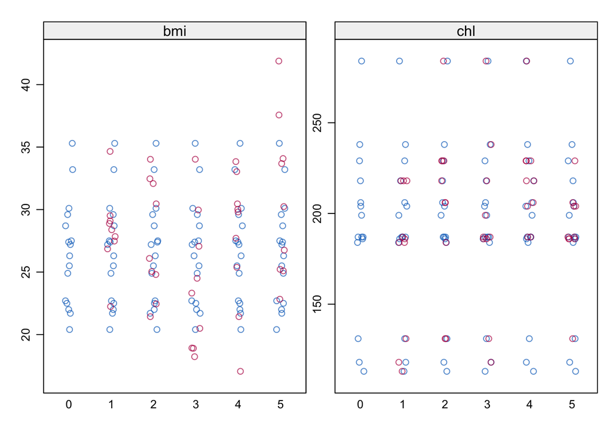

```r
stripplot(imp)
```

Remember that `bmi` was imputed by Bayesian linear regression and (the range of) imputed values may therefore be different than observed values.

# Repeated analysis in mice

**7. Perform the following regression analysis on the multiply imputed data and assign the result to object `fit`.**

$$\text{bmi} = \beta_0 + \beta_1 \text{chl} + \epsilon$$

```r
fit <- with(imp, lm(bmi ~ chl))
fit
```

```
## call :
## with.mids(data = imp, expr = lm(bmi ~ chl))
##
## call1 :
## mice(data = nhanes2, method = meth, printFlag = F)
##
## nmis :
## age bmi hyp chl
##   0   9   8  10
##
## analyses :
## [[1]]
##
## Call:
## lm(formula = bmi ~ chl)
##
## Coefficients:
## (Intercept)          chl
##    24.68267      0.01359
##
##
## [[2]]
##
## Call:
## lm(formula = bmi ~ chl)
##
## Coefficients:
## (Intercept)          chl
##    20.03732      0.03516
##
##
## [[3]]
##
## Call:
## lm(formula = bmi ~ chl)
##
## Coefficients:
## (Intercept)          chl
##    19.87987      0.02985
##
##
## [[4]]
##
## Call:
## lm(formula = bmi ~ chl)
##
## Coefficients:
## (Intercept)          chl
##    17.22495      0.04803
##
##
## [[5]]
##
## Call:
## lm(formula = bmi ~ chl)
##
## Coefficients:
## (Intercept)          chl
##    21.28350      0.03564
```

The `fit` object contains the regression summaries for each data set. The new object `fit` is actually of class `mira` (*multiply imputed repeated analyses*).

```r
class(fit)
```

```
## [1] "mira"   "matrix"
```

Use the `ls()` function to what out what is in the object.

```r
ls(fit)
```

```
## [1] "analyses" "call"     "call1"    "nmis"
```

Suppose we want to find the regression model fitted to the second imputed data set. It can be found as

```r
summary(fit$analyses[[2]])
```

```
##
## Call:
## lm(formula = bmi ~ chl)
##
## Residuals:
##    Min     1Q Median     3Q    Max
## -6.405 -3.212 -1.006  3.488  7.598
##
## Coefficients:
##             Estimate Std. Error t value Pr(>|t|)
## (Intercept) 20.03732    3.72803   5.375 1.85e-05 ***
## chl          0.03516    0.01849   1.902   0.0698 .
## ---
## Signif. codes:  0 '***' 0.001 '**' 0.01 '*' 0.05 '.' 0.1 ' ' 1
##
## Residual standard error: 4.101 on 23 degrees of freedom
## Multiple R-squared:  0.1359, Adjusted R-squared:  0.09832
## F-statistic: 3.617 on 1 and 23 DF,  p-value: 0.06979
```

**8. Pool the analyses from object `fit`.**

Pooling the repeated regression analyses can be done simply by typing

```r
pool.fit <- pool(fit)
summary(pool.fit)
```

```
##          term    estimate std.error statistic       df     p.value
## 1 (Intercept) 20.62166194 5.2696358  3.913299 10.62345 0.002584133
## 2         chl  0.03245277 0.0259197  1.252050 11.82256 0.234755284
```

```r
pool.fit
```

```
## Class: mipo    m = 5
##          term m    estimate         ubar            b            t dfcom
## 1 (Intercept) 5 20.62166194 18.961294258 7.3398063338 2.776906e+01    23
## 2         chl 5  0.03245277  0.000484987 0.0001557032 6.718309e-04    23
##         df       riv    lambda       fmi
## 1 10.62345 0.4645130 0.3171792 0.4174211
## 2 11.82256 0.3852555 0.2781115 0.3755155
```

which gives the relevant pooled regression coefficients and parameters, as well as the fraction of information about the coefficients missing due to nonresponse (`fmi`) and the proportion of the variation attributable to the missing data (`lambda`). The pooled fit object is of class `mipo`, which stands for *multiply imputed pooled object*.

`mice` can to pool many analyses from a variety of packages for you. For flexibility and in order to run custom pooling functions, mice also incorporates a function `pool.scalar()` which pools univariate estimates of $m$ repeated complete data analysis conform Rubin’s pooling rules (Rubin, 1987, paragraph 3.1)

# The `boys` data set

**9. The `boys` dataset is part of `mice`. It is a subset of a large Dutch dataset containing growth measures from the Fourth Dutch Growth Study. Inspect the help for `boys` dataset and make yourself familiar with its contents.**

To learn more about the contents of the data, use one of the two following help commands:

```r
help(boys)
?boys
```

**10. Get an overview of the data. Find information about the size of the data, the variables measured and the amount of missingness.**

The first 10 cases are:

```r
head(boys, n = 10)
```

```
##      age  hgt   wgt   bmi   hc  gen  phb tv   reg
## 3  0.035 50.1 3.650 14.54 33.7 <NA> <NA> NA south
## 4  0.038 53.5 3.370 11.77 35.0 <NA> <NA> NA south
## 18 0.057 50.0 3.140 12.56 35.2 <NA> <NA> NA south
## 23 0.060 54.5 4.270 14.37 36.7 <NA> <NA> NA south
## 28 0.062 57.5 5.030 15.21 37.3 <NA> <NA> NA south
## 36 0.068 55.5 4.655 15.11 37.0 <NA> <NA> NA south
## 37 0.068 52.5 3.810 13.82 34.9 <NA> <NA> NA south
## 38 0.071 53.0 3.890 13.84 35.8 <NA> <NA> NA  west
## 39 0.071 55.1 3.880 12.77 36.8 <NA> <NA> NA  west
## 43 0.073 54.5 4.200 14.14 38.0 <NA> <NA> NA  east
```

The last 10 cases are:

```r
tail(boys, n = 10)
```

```
##         age   hgt  wgt   bmi   hc  gen  phb tv   reg
## 7329 20.032 184.0 73.0 21.56 56.0 <NA> <NA> NA north
## 7362 20.117 188.7 89.4 25.10 58.1   G5   P6 25  east
## 7396 20.281 185.1 81.1 23.67 58.8   G5   P6 20 south
## 7405 20.323 182.5 69.0 20.71 59.0 <NA> <NA> NA north
## 7410 20.372 188.7 59.8 16.79 55.2 <NA> <NA> NA  west
## 7418 20.429 181.1 67.2 20.48 56.6 <NA> <NA> NA north
## 7444 20.761 189.1 88.0 24.60   NA <NA> <NA> NA  west
## 7447 20.780 193.5 75.4 20.13   NA <NA> <NA> NA  west
## 7451 20.813 189.0 78.0 21.83 59.9 <NA> <NA> NA north
## 7475 21.177 181.8 76.5 23.14   NA <NA> <NA> NA  east
```

We now have a clear indication that the data are sorted. A simple evaluation

```r
!is.unsorted(boys$age)
```

```
## [1] TRUE
```

confirms this - `!is.unsorted()` evaluates the complement of `is.unsorted()`, so it tests whether the data are sorted. There is no `is.sorted` function in `R`.

The dimensions of the `boys` data set are:

```r
dim(boys)
```

```
## [1] 748   9
```

We see that the `boys` data set has 748 cases over 9 variables. From those 9 variables

```r
summary(boys)
```

```
##       age              hgt              wgt              bmi
##  Min.   : 0.035   Min.   : 50.00   Min.   :  3.14   Min.   :11.77
##  1st Qu.: 1.581   1st Qu.: 84.88   1st Qu.: 11.70   1st Qu.:15.90
##  Median :10.505   Median :147.30   Median : 34.65   Median :17.45
##  Mean   : 9.159   Mean   :132.15   Mean   : 37.15   Mean   :18.07
##  3rd Qu.:15.267   3rd Qu.:175.22   3rd Qu.: 59.58   3rd Qu.:19.53
##  Max.   :21.177   Max.   :198.00   Max.   :117.40   Max.   :31.74
##                   NA's   :20       NA's   :4        NA's   :21
##        hc          gen        phb            tv           reg
##  Min.   :33.70   G1  : 56   P1  : 63   Min.   : 1.00   north: 81
##  1st Qu.:48.12   G2  : 50   P2  : 40   1st Qu.: 4.00   east :161
##  Median :53.00   G3  : 22   P3  : 19   Median :12.00   west :239
##  Mean   :51.51   G4  : 42   P4  : 32   Mean   :11.89   south:191
##  3rd Qu.:56.00   G5  : 75   P5  : 50   3rd Qu.:20.00   city : 73
##  Max.   :65.00   NA's:503   P6  : 41   Max.   :25.00   NA's :  3
##  NA's   :46                 NA's:503   NA's   :522
```

function `summary()` informs us that testicular volume `tv` has the most missings, followed by the genital and pubic hair stages `gen` and `phb`, each with 503 missing cells.

**11. As we have seen before, the function `md.pattern()` can be used to display all different missing data patterns. How many different missing data patterns are present in the boys dataframe and which pattern occurs most frequently in the data?**

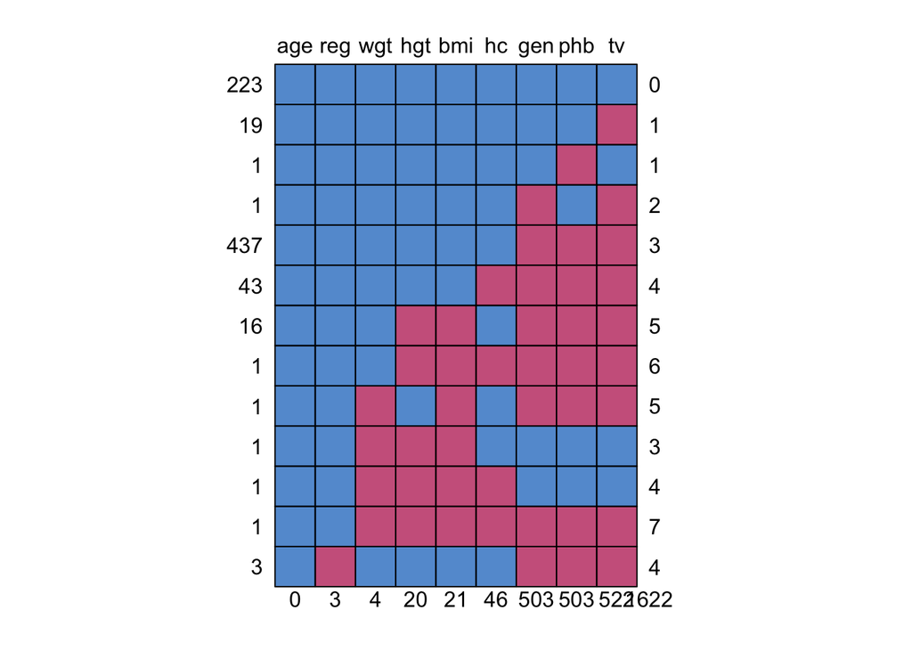

```
##     age reg wgt hgt bmi hc gen phb  tv
## 223   1   1   1   1   1  1   1   1   1    0
## 19    1   1   1   1   1  1   1   1   0    1
## 1     1   1   1   1   1  1   1   0   1    1
## 1     1   1   1   1   1  1   0   1   0    2
## 437   1   1   1   1   1  1   0   0   0    3
## 43    1   1   1   1   1  0   0   0   0    4
## 16    1   1   1   0   0  1   0   0   0    5
## 1     1   1   1   0   0  0   0   0   0    6
## 1     1   1   0   1   0  1   0   0   0    5
## 1     1   1   0   0   0  1   1   1   1    3
## 1     1   1   0   0   0  0   1   1   1    4
## 1     1   1   0   0   0  0   0   0   0    7
## 3     1   0   1   1   1  1   0   0   0    4
##       0   3   4  20  21 46 503 503 522 1622
```

```r
md.pattern(boys)
```

There are 13 patterns in total, with the pattern where `gen`, `phb` and `tv` are missing occuring the most.

**5. How many patterns occur for which the variable `gen` (genital Tannerstage) is missing?**

```r
mpat <- md.pattern(boys, plot = FALSE)
sum(mpat[, "gen"] == 0)
```

```
## [1] 8
```

Answer: 8 patterns (503 cases)

**12. Let us focus more precisely on the missing data patterns. Does the missing data of `gen` depend on `age`? One could for example check this by making a histogram of `age` separately for the cases with known genital stages and for cases with missing genital stages.**

```r
R <- is.na(boys$gen)
head(R, n = 100)
```

```
##   [1] TRUE TRUE TRUE TRUE TRUE TRUE TRUE TRUE TRUE TRUE TRUE TRUE TRUE TRUE
##  [15] TRUE TRUE TRUE TRUE TRUE TRUE TRUE TRUE TRUE TRUE TRUE TRUE TRUE TRUE
##  [29] TRUE TRUE TRUE TRUE TRUE TRUE TRUE TRUE TRUE TRUE TRUE TRUE TRUE TRUE
##  [43] TRUE TRUE TRUE TRUE TRUE TRUE TRUE TRUE TRUE TRUE TRUE TRUE TRUE TRUE
##  [57] TRUE TRUE TRUE TRUE TRUE TRUE TRUE TRUE TRUE TRUE TRUE TRUE TRUE TRUE
##  [71] TRUE TRUE TRUE TRUE TRUE TRUE TRUE TRUE TRUE TRUE TRUE TRUE TRUE TRUE
##  [85] TRUE TRUE TRUE TRUE TRUE TRUE TRUE TRUE TRUE TRUE TRUE TRUE TRUE TRUE
##  [99] TRUE TRUE
```

```r
tail(R, n = 100)
```

```
##   [1]  TRUE  TRUE  TRUE  TRUE FALSE  TRUE FALSE  TRUE  TRUE  TRUE FALSE
##  [12]  TRUE  TRUE  TRUE  TRUE FALSE  TRUE  TRUE  TRUE FALSE FALSE  TRUE
##  [23] FALSE  TRUE FALSE  TRUE  TRUE  TRUE FALSE FALSE FALSE  TRUE FALSE
##  [34]  TRUE  TRUE FALSE  TRUE  TRUE  TRUE FALSE  TRUE FALSE  TRUE  TRUE
##  [45]  TRUE FALSE FALSE  TRUE  TRUE  TRUE FALSE FALSE FALSE  TRUE FALSE
##  [56]  TRUE  TRUE  TRUE  TRUE FALSE FALSE FALSE  TRUE  TRUE FALSE  TRUE
##  [67]  TRUE  TRUE FALSE FALSE  TRUE FALSE FALSE  TRUE  TRUE FALSE FALSE
##  [78]  TRUE FALSE  TRUE FALSE FALSE  TRUE  TRUE FALSE FALSE FALSE  TRUE
##  [89] FALSE FALSE  TRUE FALSE FALSE  TRUE  TRUE  TRUE  TRUE  TRUE  TRUE
## [100]  TRUE
```

```r
length(R)
```

```
## [1] 748
```

As we can see, the missingness indicator tells us for each of the 748 values in `gen` whether it is missing (`TRUE`) or observed (`FALSE`).

A histogram can be made with the function `lattice::histogram()`.

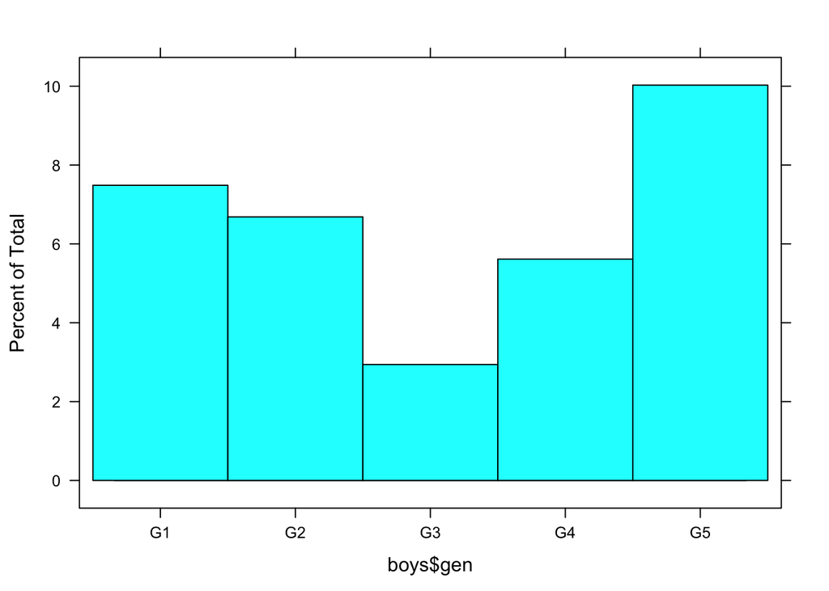

```r
lattice::histogram(boys$gen)
```

or, equivalently, one could use

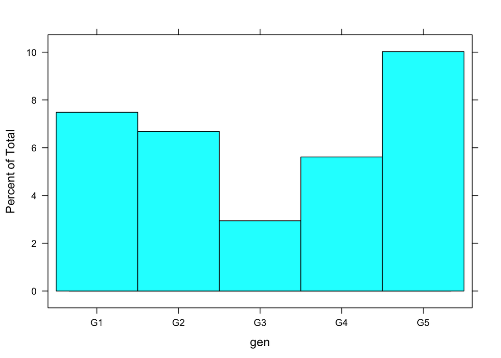

```r
lattice::histogram(~ gen, data = boys)
```

Writing the latter line of code for plots is more efficient than selecting every part of the `boys` data with the `boys$...` command, especially if plots become more advanced. The code for a conditional histogram of `age` given `R` is

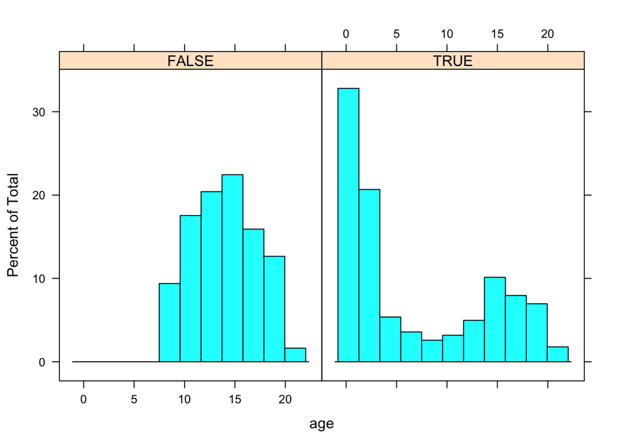

```r
lattice::histogram(~ age | R, data=boys)
```

The histogram shows that the missingness in `gen` is not equally distributed across `age`; or, equivalently, `age` seems to be differently distributed for observed and missing `gen`.

**13. Impute the `boys` dataset with mice using all default settings and name the `mids` (multiply imputed data set) object `imp`.**

```r
imp <- mice(boys, print=FALSE)
```

**8. Compare the means of the imputed data with the means of the incomplete data.** First, we calculate the observed data means:

```r
boys %>%
  select(-phb, -gen, -reg) %>%
  colMeans(na.rm = TRUE)
```

```
##        age        hgt        wgt        bmi         hc         tv
##   9.158866 132.151786  37.153187  18.068556  51.505983  11.893805
```

and then the means for the $m$ imputed sets:

```r
imp %>%
  mice::complete("all") %>%
  map(select, -phb, -gen, -reg) %>%
  map(colMeans)
```

```
## $`1`
##        age        hgt        wgt        bmi         hc         tv
##   9.158866 131.127807  37.119266  18.020388  51.600936   8.316845
##
## $`2`
##        age        hgt        wgt        bmi         hc         tv
##   9.158866 131.170722  37.147996  18.030882  51.652139   8.250000
##
## $`3`
##        age        hgt        wgt        bmi         hc         tv
##   9.158866 131.086497  37.116365  18.042580  51.647326   8.322193
##
## $`4`
##        age        hgt        wgt        bmi         hc         tv
##   9.158866 131.081150  37.152635  18.039973  51.635963   8.216578
##
## $`5`
##        age        hgt        wgt        bmi         hc         tv
##   9.158866 131.012834  37.178170  18.055628  51.600267   8.389037
```

Most means are roughly equal, except the mean of `tv`, which is much lower in the imputed data sets, when compared to the incomplete data. This makes sense because most genital measures are unobserved for the lower ages. When imputing these values, the means should decrease.

Investigating univariate properties by using functions such as `summary()`, may not be ideal in the case of hundreds of variables. To extract just the information you need, for all imputed datasets, we can make use of the `with()` function. To obtain summaries for each imputed `tv` only, type

```r
imp %>%
  with(summary(tv)) %>%
  summary()
```

```
## # A tibble: 5 x 6
##   minimum    q1 median  mean    q3 maximum
##     <dbl> <dbl>  <dbl> <dbl> <dbl>   <dbl>
## 1       1     2      4  8.32    15      25
## 2       1     2      3  8.25    15      25
## 3       1     2      3  8.32    15      25
## 4       1     2      3  8.22    15      25
## 5       1     2      3  8.39    15      25
```

And to obtain e.g. the means alone, run

```r
imp %>%
  with(mean(tv)) %>%
  summary()
```

```
## # A tibble: 5 x 1
##       x
##   <dbl>
## 1  8.32
## 2  8.25
## 3  8.32
## 4  8.22
## 5  8.39
```

# The importance of the imputation model

The `mammalsleep` dataset is part of `mice`. It contains the Allison and Cicchetti (1976) data for mammalian species. To learn more about this data, type

```r
help(mammalsleep)
```

**14. Get an overview of the data.**

Find information about the size of the data, the variables measured and the amount of missingness.

```r
head(mammalsleep)
```

```
##                     species       bw    brw sws  ps   ts  mls  gt pi sei
## 1          African elephant 6654.000 5712.0  NA  NA  3.3 38.6 645  3   5
## 2 African giant pouched rat    1.000    6.6 6.3 2.0  8.3  4.5  42  3   1
## 3                Arctic Fox    3.385   44.5  NA  NA 12.5 14.0  60  1   1
## 4    Arctic ground squirrel    0.920    5.7  NA  NA 16.5   NA  25  5   2
## 5            Asian elephant 2547.000 4603.0 2.1 1.8  3.9 69.0 624  3   5
## 6                    Baboon   10.550  179.5 9.1 0.7  9.8 27.0 180  4   4
##   odi
## 1   3
## 2   3
## 3   1
## 4   3
## 5   4
## 6   4
```

```r
summary(mammalsleep)
```

```
##                       species         bw                brw
##  African elephant         : 1   Min.   :   0.005   Min.   :   0.14
##  African giant pouched rat: 1   1st Qu.:   0.600   1st Qu.:   4.25
##  Arctic Fox               : 1   Median :   3.342   Median :  17.25
##  Arctic ground squirrel   : 1   Mean   : 198.790   Mean   : 283.13
##  Asian elephant           : 1   3rd Qu.:  48.203   3rd Qu.: 166.00
##  Baboon                   : 1   Max.   :6654.000   Max.   :5712.00
##  (Other)                  :56
##       sws               ps              ts             mls
##  Min.   : 2.100   Min.   :0.000   Min.   : 2.60   Min.   :  2.000
##  1st Qu.: 6.250   1st Qu.:0.900   1st Qu.: 8.05   1st Qu.:  6.625
##  Median : 8.350   Median :1.800   Median :10.45   Median : 15.100
##  Mean   : 8.673   Mean   :1.972   Mean   :10.53   Mean   : 19.878
##  3rd Qu.:11.000   3rd Qu.:2.550   3rd Qu.:13.20   3rd Qu.: 27.750
##  Max.   :17.900   Max.   :6.600   Max.   :19.90   Max.   :100.000
##  NA's   :14       NA's   :12      NA's   :4       NA's   :4
##        gt               pi             sei             odi
##  Min.   : 12.00   Min.   :1.000   Min.   :1.000   Min.   :1.000
##  1st Qu.: 35.75   1st Qu.:2.000   1st Qu.:1.000   1st Qu.:1.000
##  Median : 79.00   Median :3.000   Median :2.000   Median :2.000
##  Mean   :142.35   Mean   :2.871   Mean   :2.419   Mean   :2.613
##  3rd Qu.:207.50   3rd Qu.:4.000   3rd Qu.:4.000   3rd Qu.:4.000
##  Max.   :645.00   Max.   :5.000   Max.   :5.000   Max.   :5.000
##  NA's   :4
```

```r
str(mammalsleep)
```

```
## 'data.frame':    62 obs. of  11 variables:
##  $ species: Factor w/ 62 levels "African elephant",..: 1 2 3 4 5 6 7 8 9 10 ...
##  $ bw     : num  6654 1 3.38 0.92 2547 ...
##  $ brw    : num  5712 6.6 44.5 5.7 4603 ...
##  $ sws    : num  NA 6.3 NA NA 2.1 9.1 15.8 5.2 10.9 8.3 ...
##  $ ps     : num  NA 2 NA NA 1.8 0.7 3.9 1 3.6 1.4 ...
##  $ ts     : num  3.3 8.3 12.5 16.5 3.9 9.8 19.7 6.2 14.5 9.7 ...
##  $ mls    : num  38.6 4.5 14 NA 69 27 19 30.4 28 50 ...
##  $ gt     : num  645 42 60 25 624 180 35 392 63 230 ...
##  $ pi     : int  3 3 1 5 3 4 1 4 1 1 ...
##  $ sei    : int  5 1 1 2 5 4 1 5 2 1 ...
##  $ odi    : int  3 3 1 3 4 4 1 4 1 1 ...
```

As we have seen before, the function `md.pattern()` can be used to display all different missing data patterns. How many different missing data patterns are present in the `mammalsleep` dataframe and which pattern occurs most frequently in the data?

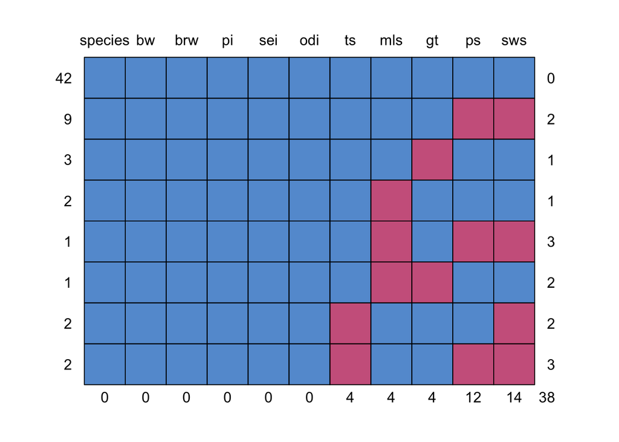

```
##    species bw brw pi sei odi ts mls gt ps sws
## 42       1  1   1  1   1   1  1   1  1  1   1  0
## 9        1  1   1  1   1   1  1   1  1  0   0  2
## 3        1  1   1  1   1   1  1   1  0  1   1  1
## 2        1  1   1  1   1   1  1   0  1  1   1  1
## 1        1  1   1  1   1   1  1   0  1  0   0  3
## 1        1  1   1  1   1   1  1   0  0  1   1  2
## 2        1  1   1  1   1   1  0   1  1  1   0  2
## 2        1  1   1  1   1   1  0   1  1  0   0  3
##          0  0   0  0   0   0  4   4  4 12  14 38
```

```r
md.pattern(mammalsleep)
```

Answer: 8 patterns in total, with the pattern where everything is observed occuring the most (42 times).

**15. Generate five imputed datasets with the default method `pmm`. Give the algorithm 10 iterations.**

```r
imp1 <- mice(mammalsleep, maxit = 10, print=F)
```

We ignore the `loggedEvents` for now: it contains a list of all decisions and exclusions that are performed by the `mice` algorithm. To inspect the trace lines for assessing algorithmic convergence:

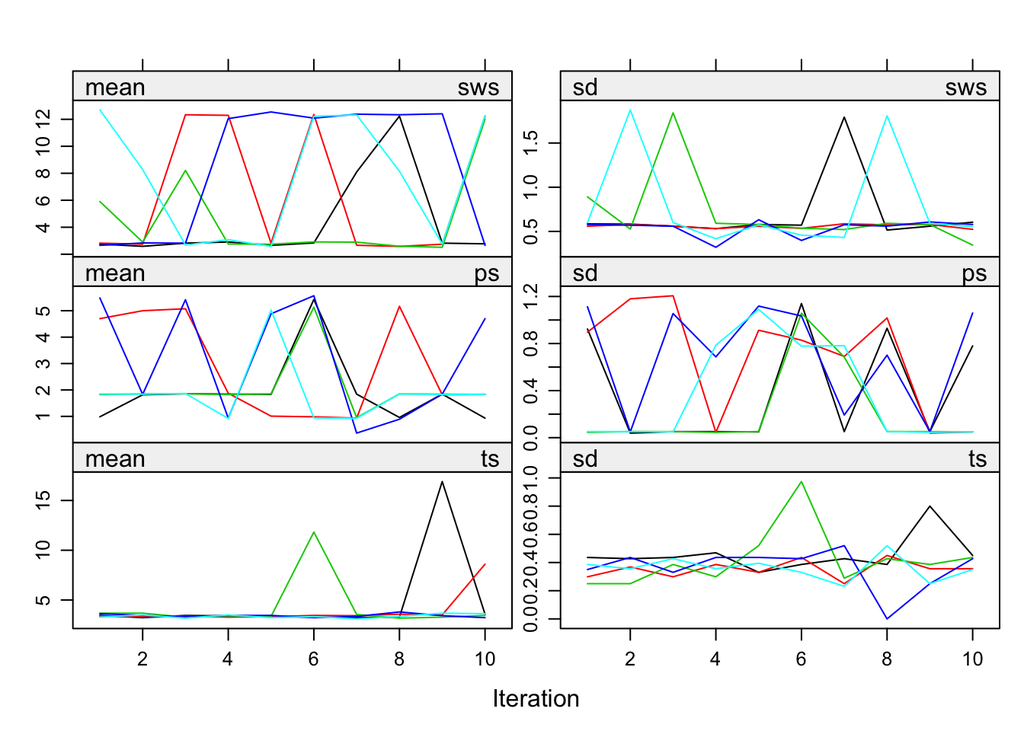

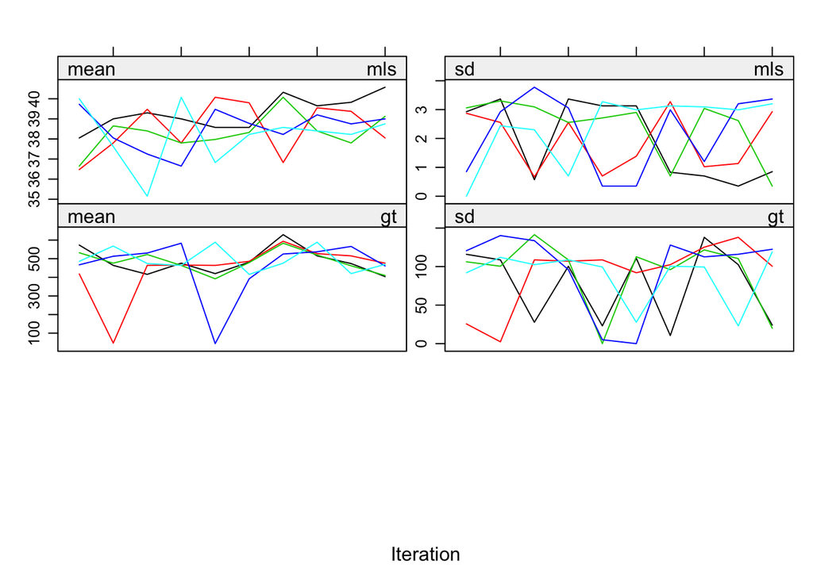

```r
plot(imp1)
```

**16. Perform a regression analysis on the imputed dataset with `sws` as dependent variable and `log10(bw)` and `odi` as independent variables.**

```r
fit1 <- with(imp1, lm(sws ~ log10(bw) + odi))
```

**17. Pool the regression analysis and inspect the pooled analysis.**

```r
est1 <- pool(fit1)
est1
```

```
## Class: mipo    m = 5
##          term m   estimate       ubar          b         t dfcom        df
## 1 (Intercept) 5 10.7723819 0.75412950 1.13323243 2.1140084    59  6.555420
## 2   log10(bw) 5 -0.9823155 0.10646004 0.43414568 0.6274349    59  3.628691
## 3         odi 5 -0.6099362 0.09428764 0.01159441 0.1082009    59 41.267343
##         riv    lambda       fmi
## 1 1.8032432 0.6432703 0.7179357
## 2 4.8936183 0.8303249 0.8815191
## 3 0.1475622 0.1285875 0.1679580
```

```r
summary(est1)
```

```
##          term   estimate std.error statistic        df      p.value
## 1 (Intercept) 10.7723819 1.4539630  7.408979  6.555420 0.0002042171
## 2   log10(bw) -0.9823155 0.7921079 -1.240128  3.628691 0.2890761571
## 3         odi -0.6099362 0.3289391 -1.854253 41.267343 0.0708589874
```

The `fmi` and `lambda` are much too high. This is due to `species` being included in the imputation model. Because there are 62 species and mice automatically converts factors (categorical variables) to dummy variables, each species is modeled by its own imputation model.

**18. Impute `mammalsleep` again, but now exclude `species` from the data.**

```r
imp2 <- mice(mammalsleep[ , -1], maxit = 10, print = F)
```

**19. Compute and pool the regression analysis again.**

```r
fit2 <- with(imp2, lm(sws ~ log10(bw) + odi))
est2 <- pool(fit2)
est2
```

```
## Class: mipo    m = 5
##          term m   estimate       ubar           b          t dfcom
## 1 (Intercept) 5 11.4855242 0.58584218 0.031040507 0.62309078    59
## 2   log10(bw) 5 -1.1422475 0.08270302 0.012160106 0.09729514    59
## 3         odi 5 -0.8627441 0.07324694 0.002829234 0.07664202    59
##         df        riv     lambda        fmi
## 1 51.22657 0.06358130 0.05978039 0.09445784
## 2 38.12768 0.17644009 0.14997797 0.19131373
## 3 53.14485 0.04635116 0.04429790 0.07834206
```

```r
summary(est2)
```

```
##          term   estimate std.error statistic       df      p.value
## 1 (Intercept) 11.4855242 0.7893610 14.550408 51.22657 0.0000000000
## 2   log10(bw) -1.1422475 0.3119217 -3.661969 38.12768 0.0007566175
## 3         odi -0.8627441 0.2768430 -3.116367 53.14485 0.0029515193
```

Note that the `fmi` and `lambda` have dramatically decreased. The imputation model has been greatly improved.

**20. Plot the trace lines for the new imputations**

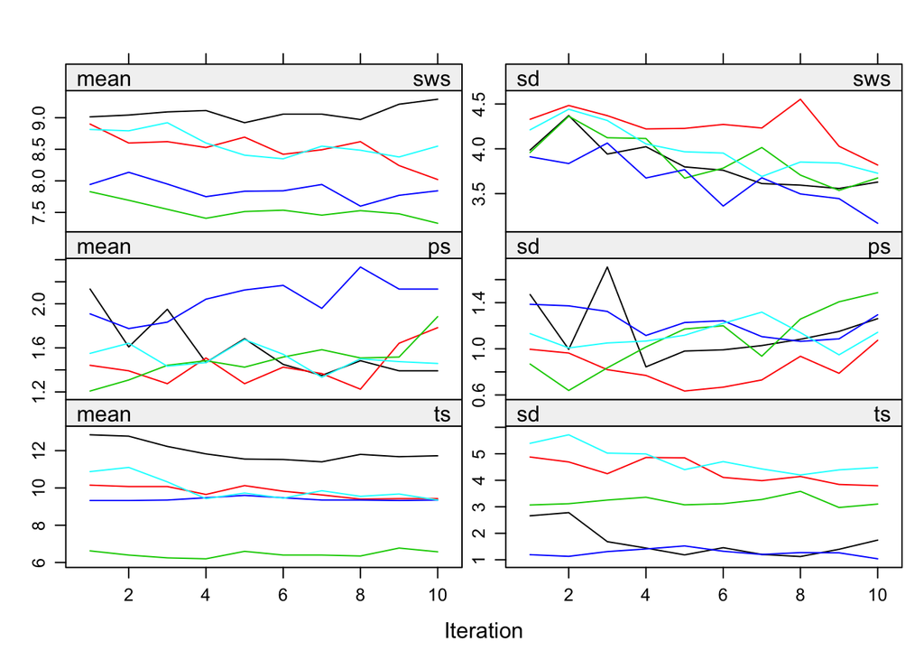

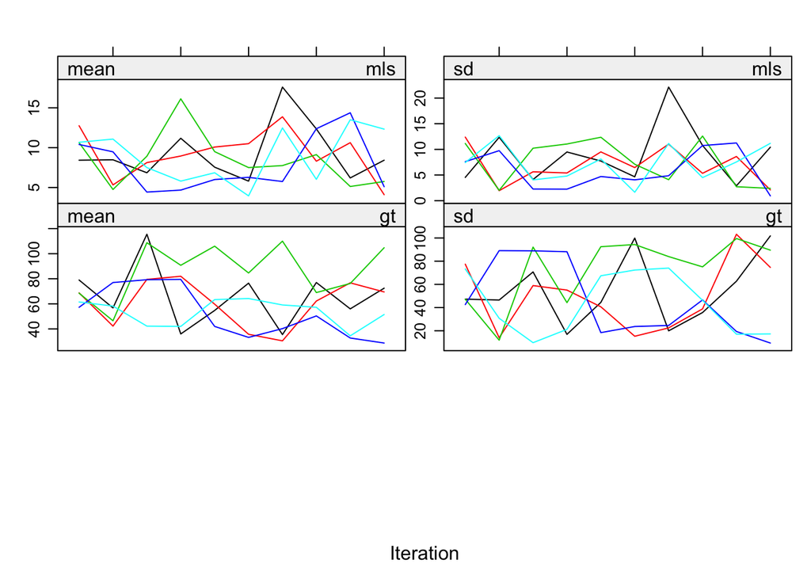

```r
plot(imp2)
```

Even though the fraction of information missing due to nonresponse (fmi) and the relative increase in variance due to nonresponse (lambda) are nice and low, the convergence turns out to be a real problem. The reason is the structure in the data. Total sleep (`ts`) is the sum of paradoxical sleep (`ps`) and short wave sleep (`sws`). This relation is ignored in the imputations, but it is necessary to take this relation into account. `mice` offers a routine called *passive imputation*, which allows users to take transformations, combinations and recoded variables into account when imputing their data.

# Passive Imputation

There is often a need for transformed, combined or recoded versions of the data. In the case of incomplete data, one could impute the original, and transform the completed original afterwards, or transform the incomplete original and impute the transformed version. If, however, both the original and the transformed version are needed within the imputation algorithm, neither of these approaches work: One cannot be sure that the transformation holds between the imputed values of the original and transformed versions. `mice` has a built-in approach, called *passive imputation*, to deal with situations as described above. The goal of passive imputation is to maintain the consistency among different transformations of the same data. As an example, consider the following deterministic function in the `boys` data
$$\text{BMI} = \frac{\text{Weight (kg)}}{\text{Height}^2 \text{(m)}}$$
or the compositional relation in the mammalsleep data:
$$\text{ts} = \text{ps}+\text{sws}$$

**22. Use passive imputation to impute the deterministic sleep relation in the `mammalsleep` data. Name the new multiply imputed dataset `pas.imp`.**

First, we create a `method` vector:

```r
meth <- make.method(mammalsleep)
meth
```

```
## species      bw     brw     sws      ps      ts     mls      gt      pi
##      ""      ""      ""   "pmm"   "pmm"   "pmm"   "pmm"   "pmm"      ""
##     sei     odi
##      ""      ""
```

and a `predictorMatrix`:

```r
pred <- make.predictorMatrix(mammalsleep)
pred
```

```
##         species bw brw sws ps ts mls gt pi sei odi
## species       0  1   1   1  1  1   1  1  1   1   1
## bw            1  0   1   1  1  1   1  1  1   1   1
## brw           1  1   0   1  1  1   1  1  1   1   1
## sws           1  1   1   0  1  1   1  1  1   1   1
## ps            1  1   1   1  0  1   1  1  1   1   1
## ts            1  1   1   1  1  0   1  1  1   1   1
## mls           1  1   1   1  1  1   0  1  1   1   1
## gt            1  1   1   1  1  1   1  0  1   1   1
## pi            1  1   1   1  1  1   1  1  0   1   1
## sei           1  1   1   1  1  1   1  1  1   0   1
## odi           1  1   1   1  1  1   1  1  1   1   0
```

We add the call for passive imputation to the `ts` element in the `meth` object

```r
meth["ts"]<- "~ I(sws + ps)"
meth
```

```
##         species              bw             brw             sws
##              ""              ""              ""           "pmm"
##              ps              ts             mls              gt
##           "pmm" "~ I(sws + ps)"           "pmm"           "pmm"
##              pi             sei             odi
##              ""              ""              ""
```

and set the predictor relations for `ts` with `sws` and `ps` to `0`. Also, we have to exclude `Species` as a predictor

```r
pred[c("sws", "ps"), "ts"] <- 0
pred[, "species"] <- 0
pred
```

```
##         species bw brw sws ps ts mls gt pi sei odi
## species       0  1   1   1  1  1   1  1  1   1   1
## bw            0  0   1   1  1  1   1  1  1   1   1
## brw           0  1   0   1  1  1   1  1  1   1   1
## sws           0  1   1   0  1  0   1  1  1   1   1
## ps            0  1   1   1  0  0   1  1  1   1   1
## ts            0  1   1   1  1  0   1  1  1   1   1
## mls           0  1   1   1  1  1   0  1  1   1   1
## gt            0  1   1   1  1  1   1  0  1   1   1
## pi            0  1   1   1  1  1   1  1  0   1   1
## sei           0  1   1   1  1  1   1  1  1   0   1
## odi           0  1   1   1  1  1   1  1  1   1   0
```

This avoids circularity problems where `ts` would *feed back into* `sws` and `ps`, from which it is calculated:

We can then run the imputations as

```r
pas.imp <- mice(mammalsleep,
                meth = meth,
                pred = pred,
                maxit = 10,
                seed = 123,
                print = F)
```

We used a custom predictor matrix and method vector to tailor our imputation approach to the passive imputation problem. We made sure to exclude `ts` as a predictor for the imputation of `sws` and `ps` to avoid circularity.

We also gave the imputation algorithm 10 iterations to converge and fixed the seed to `123` for this `mice` instance. This means that even when people do not fix the overall `R` seed for a session, exact replication of results can be obtained by simply fixing the `seed` for the random number generator within `mice`. Naturally, the same input (data) is each time required to yield the same output (`mids`-object).

# Conclusion

We have seen that the practical execution of multiple imputation and pooling is straightforward with the `R` package `mice`. The package is designed to allow you to assess and control the imputations themselves, the convergence of the algorithm and the distributions and multivariate relations of the observed and imputed data.

It is important to ‘gain’ this control as a user. After all, we are imputing values and we aim to properly adress the uncertainty about the missingness problem.

# Additional materials

A more detailed practical guide to `mice` in `R` can be found [here](https://www.gerkovink.com/miceVignettes/)

# References

Rubin, D. B. *Multiple imputation for nonresponse in surveys*. John Wiley & Sons, 1987. [Amazon](http://www.amazon.com/Multiple-Imputation-Nonresponse-Surveys-Donald/dp/0471655740/ref=sr_1_1?ie=UTF8&qid=1434466788&sr=8-1&keywords=Multiple+imputation+for+nonresponse+in+surveys)

Schafer, J.L. (1997). *Analysis of Incomplete Multivariate Data*. London: Chapman & Hall. Table 6.14. [Amazon](http://www.amazon.com/Incomplete-Multivariate-Monographs-Statistics-Probability/dp/0412040611/ref=sr_1_1?ie=UTF8&qid=1434466828&sr=8-1&keywords=Analysis+of+Incomplete+Multivariate+Data)

Van Buuren, S. and Groothuis-Oudshoorn, K. (2011). mice: Multivariate Imputation by Chained Equations in R. *Journal of Statistical Software*, 45(3), 1-67. [pdf](http://www.jstatsoft.org/v45/i03/paper)

**- End of practical**